# Case Predição Preço de Imóvel - FIA

Marcio Fernandes Cruz

27/06/2021

## Case

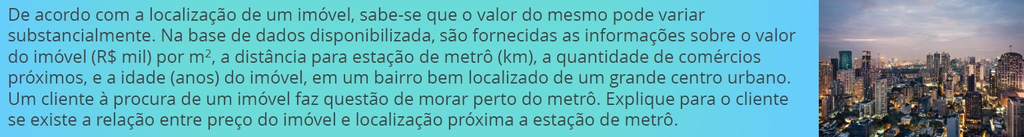

Predição de preços de imóveis - Regressão Linear Simples

### Hipóteses para β1:

#### Ho: β1 = 0 (não existe relação linear entre as variáveis)

#### Ha: β1 # 0 (existe relação linear entre as variáveis)

### Hipóteses para β0:

#### Ho: β0 = 0 (não existe relação linear entre as variáveis)

#### Ha: β0 # 0 (existe relação linear entre as variáveis)

### a) Faça o gráfico de dispersão entre as veriáveis Distância_metro_Km e Mil_reais_m2. Existe relação entre preço do imóvel e distância para o metrô? É positiva ou negativa?

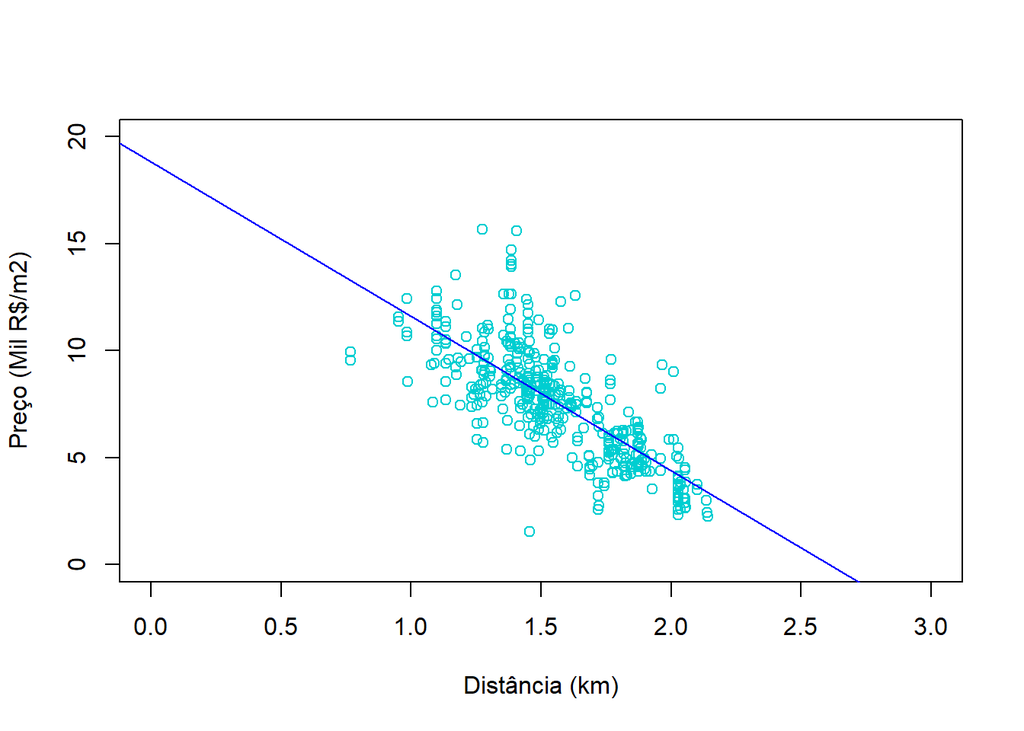

### b) Calcule o coeficiente de correlação linear entre as duas variáveis e interprete o coeficiente.

```r
correlacao = cor(imobiliario$ Distancia_metro_Km, imobiliario$Mil_reais_m2)
```

**Interpretação:** Existe uma correlação forte e negativa (r = -0.756) entre as variáveis de preço por metro quadrado e distância ao metrô.

### c) Por meio do modelo de regressão linear simples, teste se existe relação linear entre as variáveis considerando 90% de confiança.

#### Teste β1

```r
regressao.b1 <- lm(data=imobiliario, Mil_reais_m2 ~ Distancia_metro_Km)

summary(regressao.b1)
```

```
##
## Call:
## lm(formula = Mil_reais_m2 ~ Distancia_metro_Km, data = imobiliario)
##
## Residuals:
##     Min      1Q  Median      3Q     Max
## -6.7759 -0.9554 -0.1587  0.7327  6.9331
##
## Coefficients:
##                    Estimate Std. Error t value            Pr(>|t|)
## (Intercept)         18.8154     0.4882   38.54 <0.0000000000000002 ***
## Distancia_metro_Km  -7.2166     0.3082  -23.41 <0.0000000000000002 ***
## ---
## Signif. codes:  0 '***' 0.001 '**' 0.01 '*' 0.05 '.' 0.1 ' ' 1
##
## Residual standard error: 1.71 on 411 degrees of freedom
## Multiple R-squared:  0.5715, Adjusted R-squared:  0.5705
## F-statistic: 548.2 on 1 and 411 DF,  p-value: < 0.00000000000000022
```

O pvalor (0.0000000000000002) < 0,10 indica que devemos rejeitar a hipótese nula, ou seja, aceitar que existe relação linear entre as variáveis.

### d) Interprete os parâmetros do modelo e o coeficiente de determinação.

R2 é 0,5715: 57,15% dos preços de imóveis é explicado pela distância ao metrô, indicando um bom ajuste do modelo aos dados.

### e) Apresente a equação do modelo estimada.

y = 18.8154 - 7.2166 * x

### f) Estime o valor do m2 do imóvel caso o cliente desejasse morar a 1 km do metrô.

O valor estimado do imóvel a 1 Km do metrô é R$ 11.60

### g) Para este cliente que deseja morar a 1km do metrô, estimo o valor a ser pago em um apartamento de 70 m2

O valor estimado de um apartametno de 70m2 a a 1 Km do metrô é R$ 811916.00